# Final Project Information

# Final Projects

- For your final project, you’ll create a scale to measure a **construct** you’re interested in, and use a convenience sample to assess the validity of your instrument and/or test some hypotheses related to your chosen construct.
- A **construct** here just means a abstract concept or idea you’re trying to measure concretely. Think of things like “support for political violence”, “fear of spiders”, or “depression”.

# Final Projects

Goals:

- Demonstrating that your chosen method of measurement “works”.
- Identifying some predictors or potential causes of the characteristic(s) you want to study.

## Requirements

What you select is up to you, but your project must meet these requirements:

- Your chosen construct must be measured using multiple likert-type items that can be aggregated to form one or more additive scales.
- You must include at least two other measures in your survey that capture related constructs. One of your measures should be something you expect to correlate positively with your scale. The other measure should be something you expect to correlate negatively.
- One of your scale measures should be original, but your other measures should be taken from peer reviewed literature and/or established surveys.

# Finding a Scale/Reviewing the literature

- In addition to an instrument you develop yourself, your final projects require you to include two other constructs that have been used in established literature.
- Finding a validated instrument relevant to your topic may required a little detective work.
- At a minimum, you want to find a citation for your scale, the question(s) used, and the scoring method.

# Finding a scale

Your best bet is probably going to be searching journal articles in the relevant field. Some good general search engines for academic research are:

- [Google Scholar](https://scholar-google-com.proxy-um.researchport.umd.edu/).
- [Web of Science](https://www-webofscience-com.proxy-um.researchport.umd.edu/wos/woscc/smart-search)
- [Semantic Scholar](https://www.semanticscholar.org/)

# Accessing library resources

- The UMD library provides access to a ton of scholarly sources. You can access these freely any time you’re on campus.
- If you’re not on campus, you can use the [UMD reload button](https://lib.guides.umd.edu/reload-button/home) to redirect your request through the library proxy.

## Using a search engine

- Searching [“social media addiction” on Web of science turns up](https://www-webofscience-com.proxy-um.researchport.umd.edu/wos/woscc/summary/24907006-7e6c-4d64-afde-bd8d22838542-019f5842e6/2a2c5067-512e-4a69-a60b-3ae21e755b39-019f5842e2/relevance/1) lots of documents.

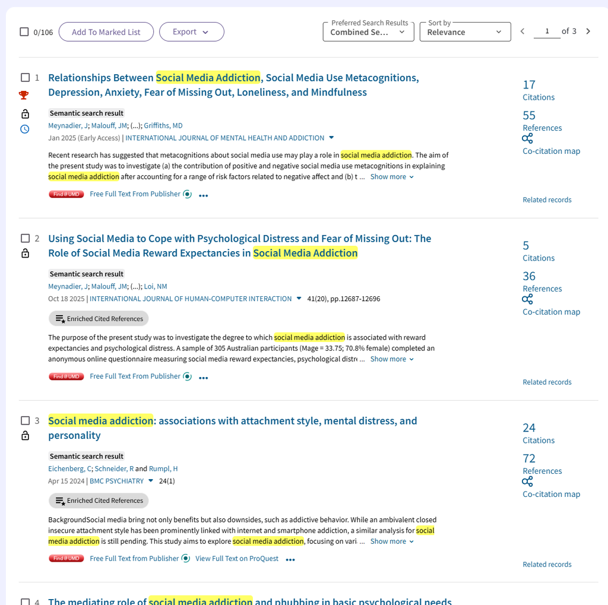

## Using a search engine

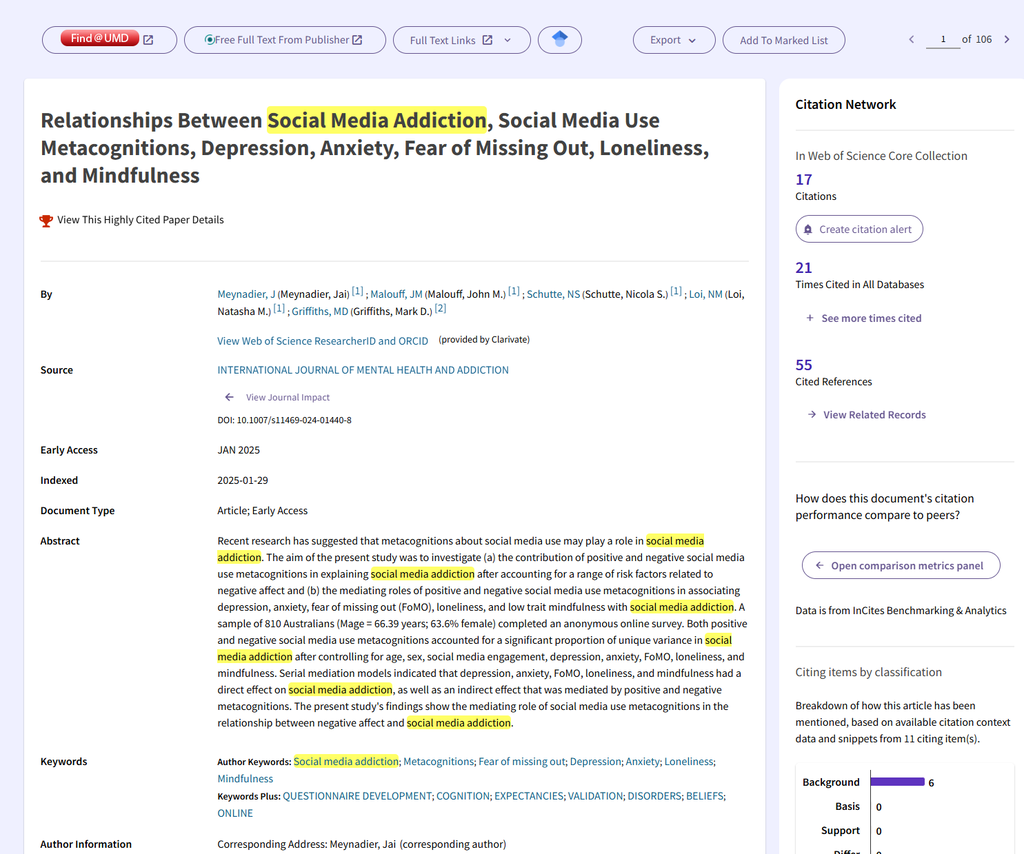

## Using a search engine

- This section lists the journal where the article was published. You should look for peer-reviewed sources.
- Journal impact factor is an (imperfect) method of measuring the prestige of an academic journal using a weighted measure of citations.

[figure not shown]

## Using a search engine

- The abstract section will briefly summarize the article and the most important findings.

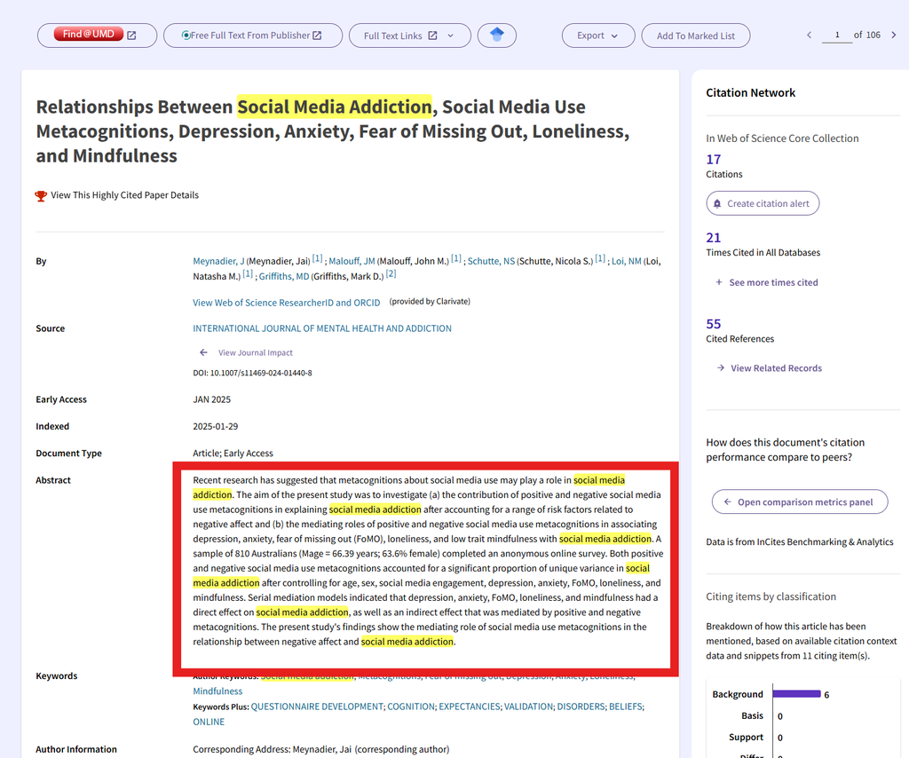

## Using a search engine

- There are some additional keywords here that might be helpful guides.
- For this project, you should keep an eye out for terms like “questionnaire development”, “validation” etc.

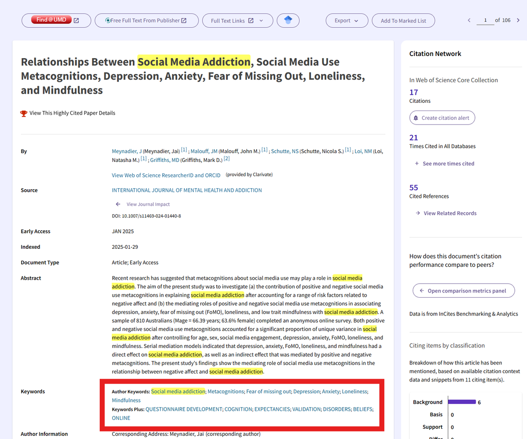

## Using a search engine

- Web of science also links papers together using their citation networks, so this is a useful thread to pull if you want to find more literature on the same topic.

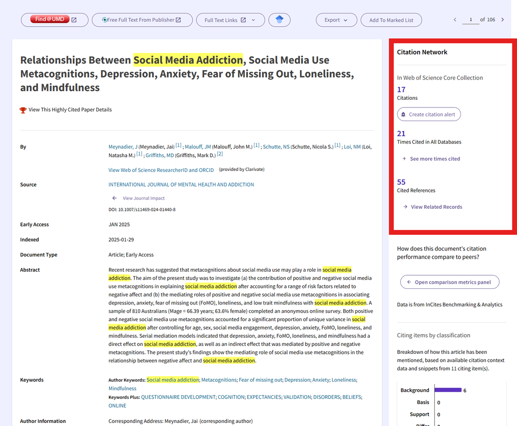

## Using a search engine

- Since I’m using the UMD proxy, a Find@UMD link shows up that will take me to a page where I can find the full text of the article.
- In this case, the full text is freely available from the publisher.

[figure not shown]

## Examining the paper

- Academic articles tend to have a relatively consistent structure. You don’t need to read the whole thing to get useful information.
- For our purposes here, the “methods” and “literature review” sections are probably the most important components.

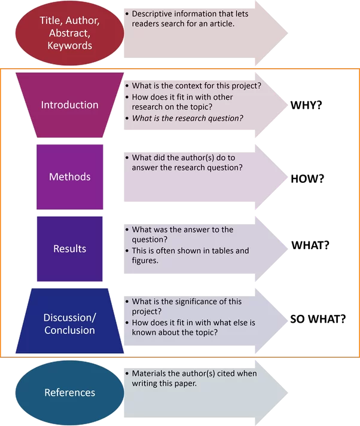

[source](https://peachyessay.com/blogs/writing-research-paper/)

## Examining the paper

- In the “methods” for this paper, there’s a heading called “measures” where the authors describe how they went about measure the key variables for their model.

[figure not shown]

## Examining the paper

[figure not shown]

## Examining the paper

- The critical component is the citation for the Bergen Social Media Addiction Scale.

[figure not shown]

## Examining the paper

- The critical component is the citation for the Bergen Social Media Addiction Scale.
- This is the original citation for the scale they’re using, so you would want to track down this article for yourself.

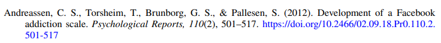

## Examining the paper

- If the questions are available, you’ll often find them listed in the appendix at the end, or in the supplementary materials, or with a link to a webpage.

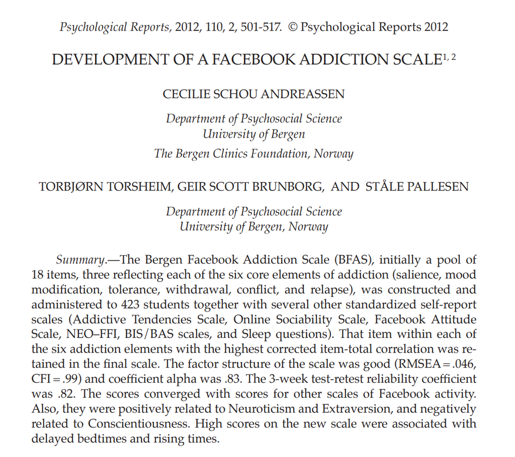

## Examining the paper

- If the questions are available, you’ll often find them listed in the appendix at the end, or in the supplementary materials, or with a link to a webpage.
- In this article, the questions used are listed in the appendix.

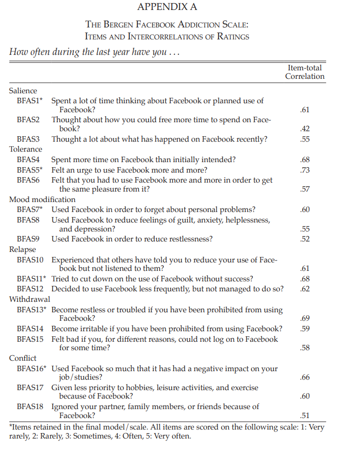

## Questions to ask

- Is the scale widely used? The citation count for the original publication can be a good indicator.

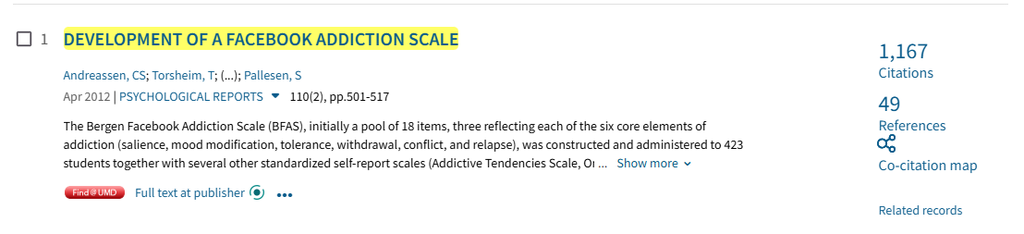

## Questions to ask: versions

- Are there different versions of the scale that might be more relevant for your project? (shorter versions, updates, minor modifications for similar constructs)

## Questions to ask: validation studies

- Have there been additional validation studies?
- Widely used scales might have been subjected to multiple validation studies to examine how well they work and what they measure

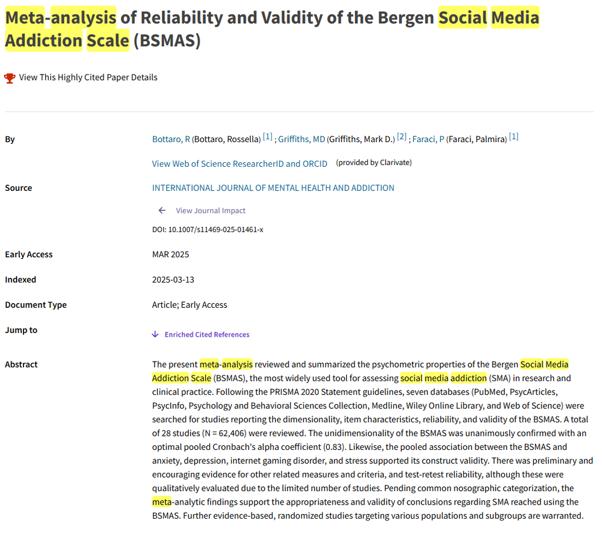

## Questions to ask: validation studies

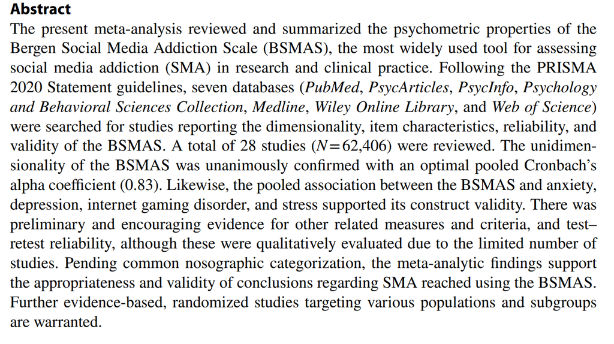

## Questions to ask: validation studies

- A meta-analysis is a study that systematically reviews and aggregates the results of previous studies.

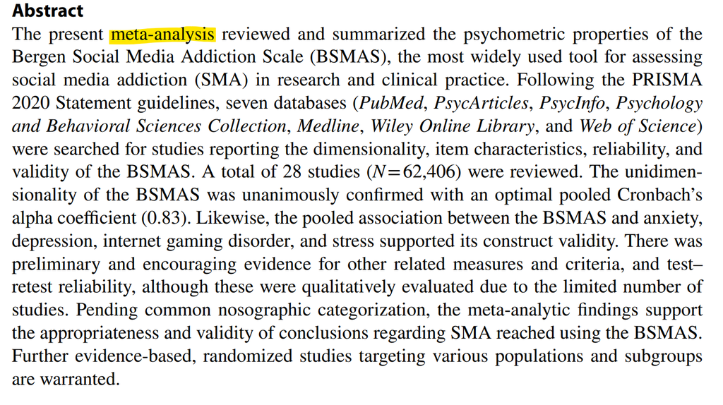

## Questions to ask: validation studies

- Dimensionality refers to the estimated number of latent constructs measured by the instrument (this is typically measured with some form of factor analysis)
- Unidimensionality indicates that there’s evidence that a single trait explains most of the variation in responses to the scale items.

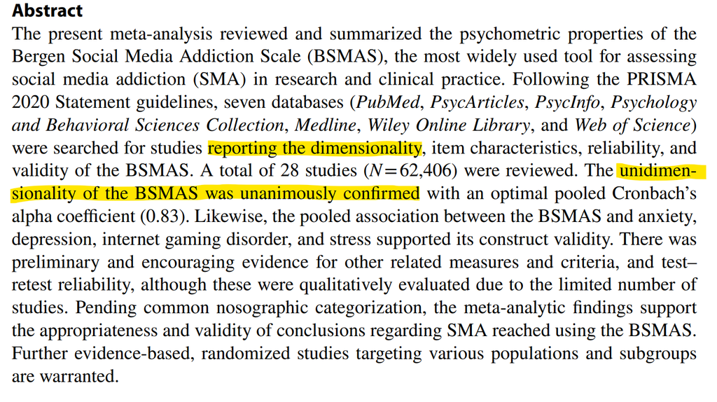

## Questions to ask: validation studies

- Evidence of construct validity comes from examining how well this measure correlates with other things that should be associated with social media addiction.
- (The abstract says these are “pooled” because they’re based on a weighted average of multiple studies.)

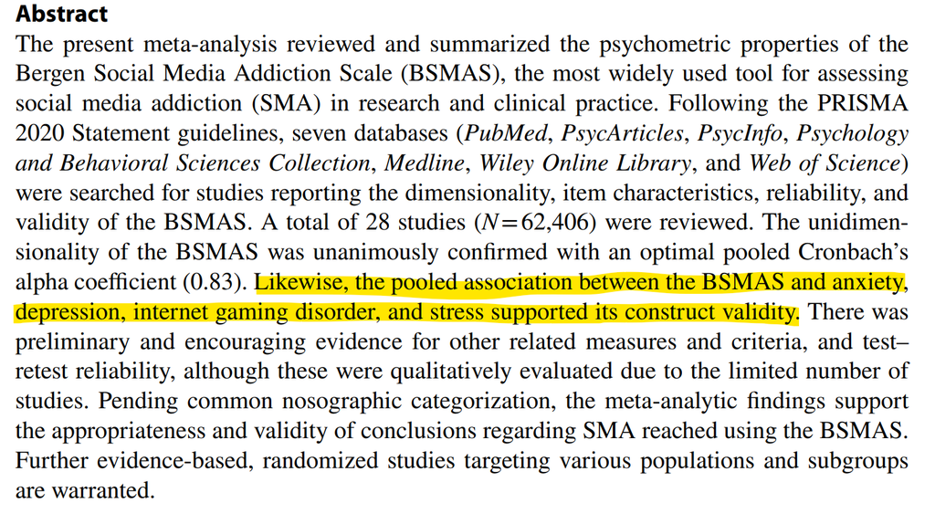

## Questions to ask: validation studies

- Test-retest reliability is an indication of how closely responses correlate between follow-ups.
- (There weren’t enough papers to quantitatively evaluate this)

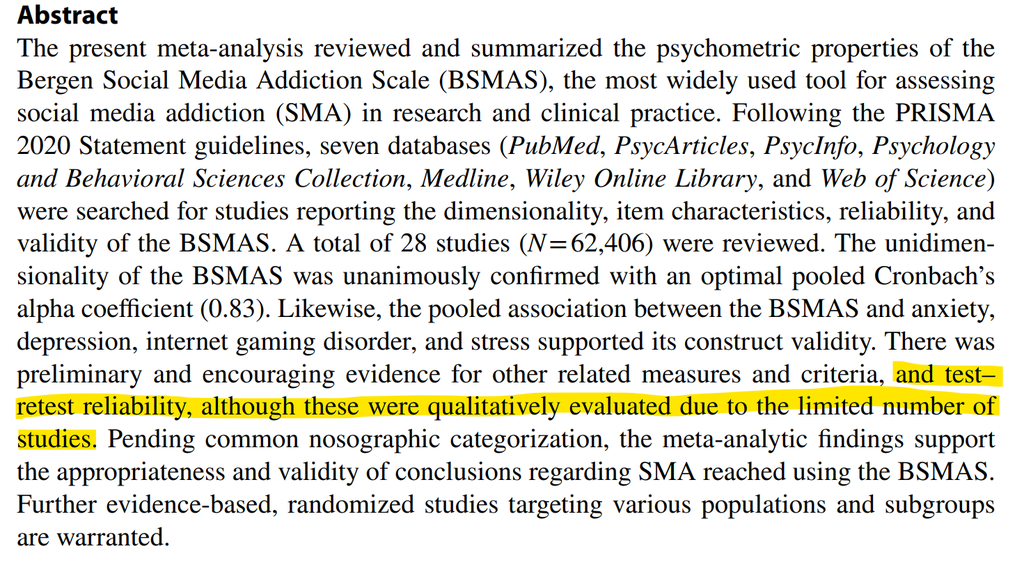

## Questions to ask: validation studies

- Social media addiction is not a recognized psychiatric disorder, so this isn’t a clinical diagnostic tool, but it appears good enough to use to draw conclusions about problematic social media use in the population.

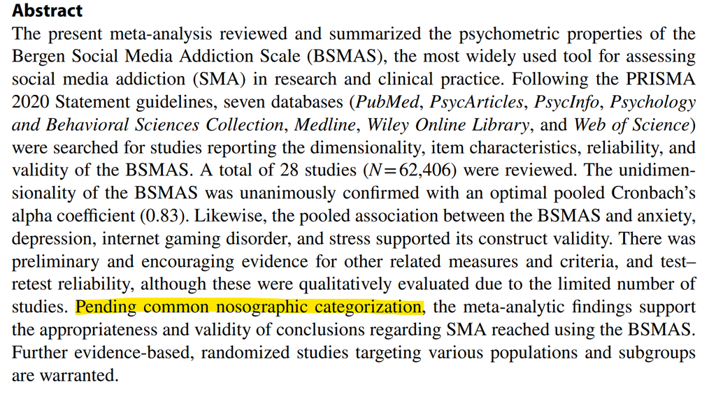

## Links and other resources

- [UMD library guide for psychology majors on finding tests and assessments.](https://lib.guides.umd.edu/c.php?g=327087&p=3471586)
- The Leibniz Institute for the Social Sciences hosts an excellent [open-access repository for m measurement instruments](https://zis.gesis.org/?lang=en) along with citations and validation information. Note that some of these are not available in English.

## Questions

- What scale or scale(s) are available?
- Are the items accessible? Are there multiple versions? How many questions and how are they scored?
- Are there additional validation studies? Can you find discussions about the reliability or dimensionality of the measure?
- Is the scale widely used? Are there important criticisms or limitations mentioned? Is there a debate that warrants consideration? Competing measures?

## Scales

- Sleepiness/Sleep deprivation
- Curiosity
- Sexism
- Pro-environmental behavior
- Belief in conspiracies
- Openness to new experiences
- Deceptiveness, lying, or manipulative behavior